# Coal Plants Selection Criteria

Robert Cline

10/21/2021

#### Coal Plants

Coal Plants included in this analysis are selected based upon the following Criteria obtained from the [European Coal Database (ECD)](https://beyond-coal.eu/database/) database:[^1]  
* Greater than 800 MW per year.  
* Closing dates between January 2018 up to and including planned closings in the year 2029.

#### Lignite Plants

The $CO_2$ emissions for lignite are predicted based upon the formula:  
*fit* <- lm($CO_2$ ~ MW, data= lignite) where lignite is the tonnes of $CO_2$ production per year from lignite fuel type.

Lignite plants are selected based upon the estimation of $CO_2$ emissions greater than **6.1093476^{6} tonnes** of coal per year which is the prediction of 800 MW per year production capacity.

CO2 Emissions as MW Predictor for Lignite Coal Plant

|  | co 2 |  |  |
| --- | --- | --- | --- |
| Predictors | Estimates | CI | p |
| (Intercept) | 814183.87 | 291327.88 – 1337039.85 | **2.386e-03** |
| MW | 6618.95 | 6322.56 – 6915.35 | **1.808e-128** |
| Observations | 285 |  |  |
| R<sup>2</sup> / R<sup>2</sup> adjusted | 0.872 / 0.872 |  |  |

#### Hard Coal Plants

Hard coal coal plants are selected based upon the estimation of $CO_2$ emissions greater than **2.7542938^{6} tonnes** of coal per year representing 800 MW and greater production capacity.

CO2 Emissions as MW Predictor for Coal Plant with hard coal fuel type

|  | co 2 |  |  |
| --- | --- | --- | --- |
| Predictors | Estimates | CI | p |
| (Intercept) | 485067.39 | 341736.44 – 628398.34 | **6.770e-11** |
| MW | 2836.53 | 2616.57 – 3056.50 | **1.049e-96** |
| Observations | 600 |  |  |
| R<sup>2</sup> / R<sup>2</sup> adjusted | 0.518 / 0.517 |  |  |

### Analysis of Residuals of fitted linear models

The analyis of the residuals of the fitted linear models suggest that the linear models represent, not perfect, but reasonable predictors of $CO_2$ emissions to predict a coal plant’s power capacity, particularly within the interquartile range.

### Hard Coal Residuals

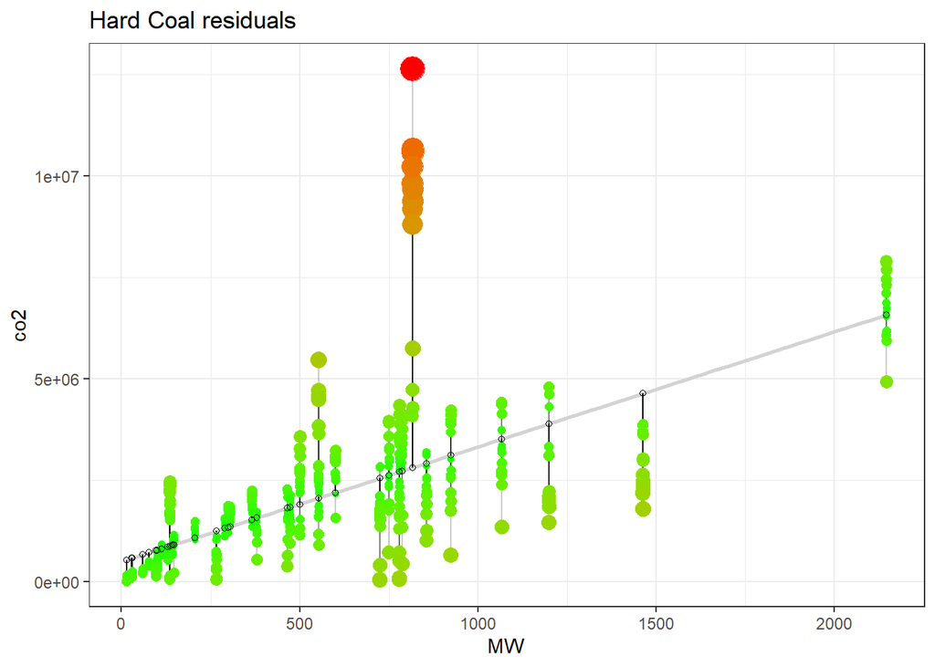

**Residuals vs Fitted** residuals should be equally spread around the horizontal lline without a distinct pattern

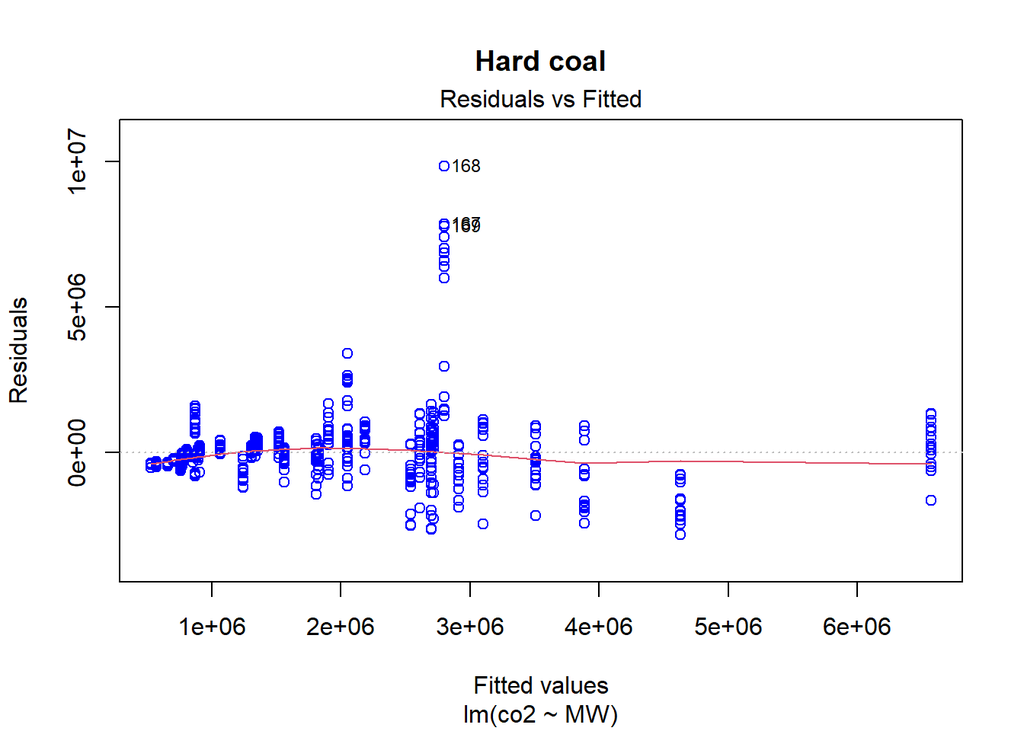

**Q-Q plot** residuals should show reasonable alignment with fit line

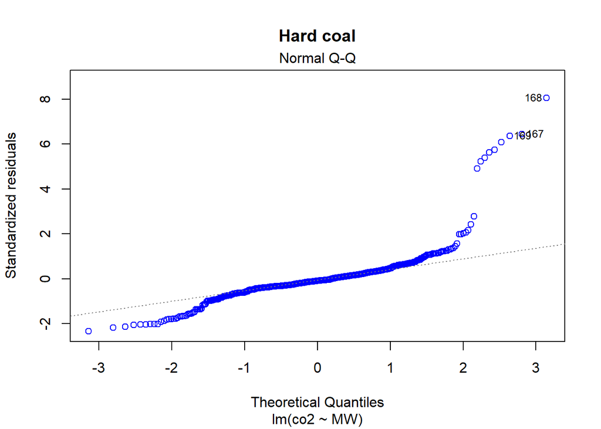

### Lignite residuals

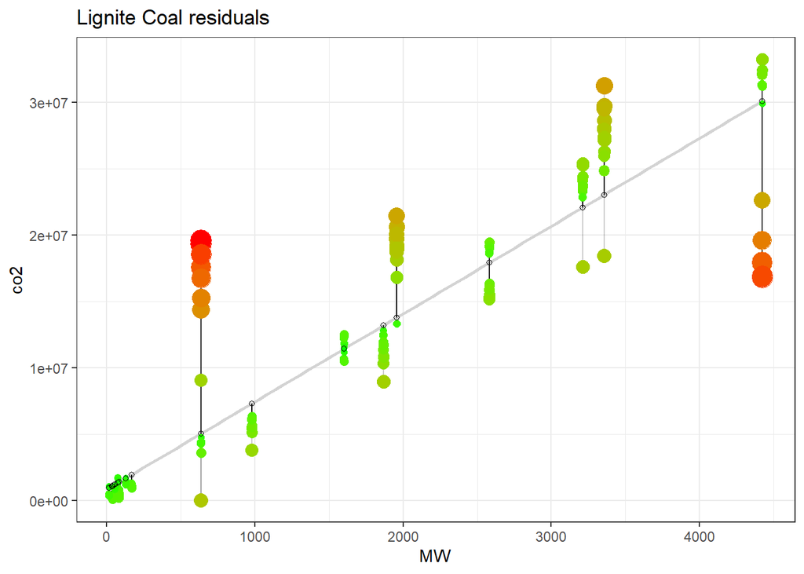

**Residuals vs Fitted** residuals should be equally spread around the horizontal lline without a distinct pattern

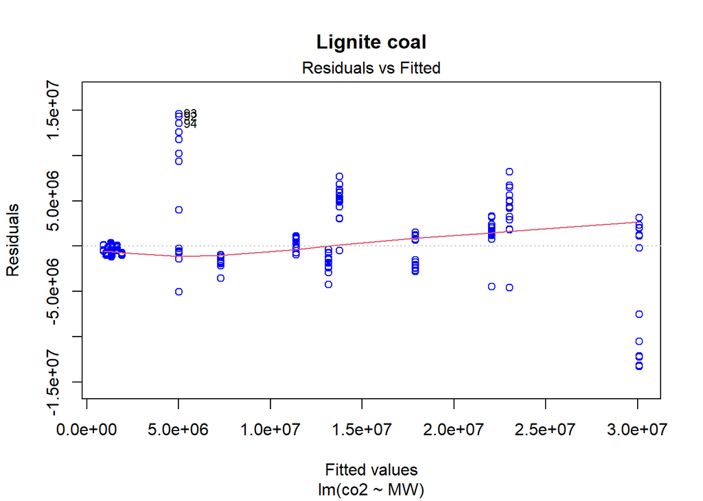

**Q-Q plot** residuals should show reasonable alignment with fit line

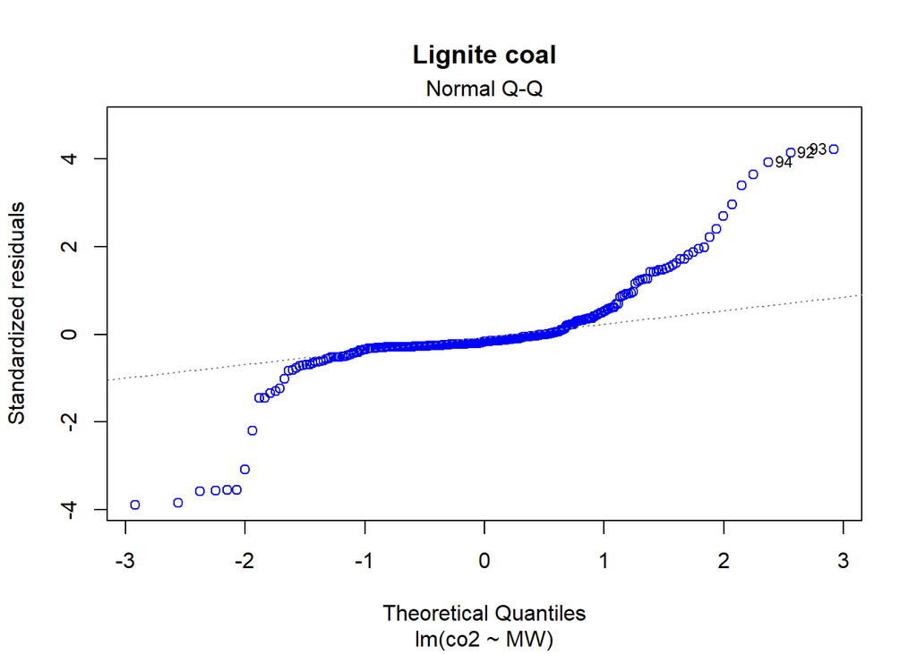

**Scale-Location** residuals should be spaced equally above and below the line

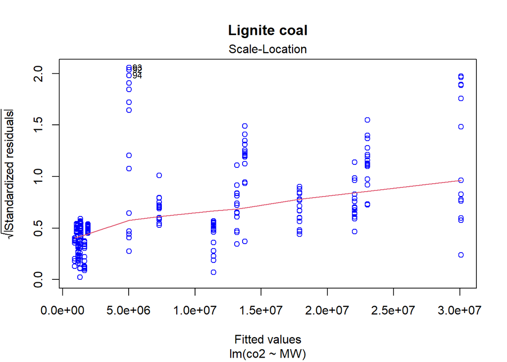

[^1]: 1. Under license an Open Database License (ODbL) v1.0. The full license can be found [here](https://opendatacommons.org/licenses/odbl/1-0/).